# Análises do SIVEP-Gripe casos de H1N1 e COVID-19

27/05/2021

Nesse relatório analisaremos algumas variáveis nas pandemias de H1N1 e da COVID-19. Além disso, nosso foco será comparar dentro dessas pandemias os grupos de gestantes versus não gestantes. E por útlimo, faremos uma breve análise dentro do grupo de gestantes nas duas pandemias (ideia para o 2º artigo).

A base de dados da pandemia de H1N1 utilizada foi a base SIVEP-Gripe (Sistema de Informação da Vigilância Epidemiológica da Gripe) de 2009 e de 2010 filtrada com os casos confirmados para H1N1 e teste pcr positivo, de mulheres em idade fértil (10 a 49 anos) gestantes e não gestantes, entre maio de 2009 a maio de 2010 e pacientes que tiveram pelo menos um sintoma(preenchido).

Já os dados da pandemia de COVID-19 foram obtidos a partir da filtragem da base de dados SIVEP-Gripe (Sistema de Informação da Vigilância Epidemiológica da Gripe) de 2020 e de 2021, com os casos confirmados para COVID-19, de mulheres em idade fértil (10 a 49 anos) gestantes e não gestantes, entre março de 2020 a março de 2021.

Inicialmente, iremos fazer uma breve análise dos critérios de diagnósticos utilizados na pandemia de COVID-19, (para H1N1 já foi realizado essa mesma análise), sendo eles: Critério clínico e critério laboratorial. Para essa análise, inicialmente a base de dados não terá o filtro de PCR positivo e de pacientes que tiveram pelo menos um sintoma(preenchido).

```r
#tabela de frequencia para resultado do PCR
questionr::freq(
  dados_covid$criterio,
  cum = FALSE,
  total = TRUE,
  na.last = FALSE,
  valid = FALSE
) %>%
  kable(caption = "Tabela de frequências para Critério", digits = 2)
```

Tabela de frequências para Critério

|  | n | % |
| --- | --- | --- |
| Clínico | 3126 | 2.9 |
| Laboratorial | 95290 | 89.5 |
| NA | 8080 | 7.6 |
| Total | 106496 | 100.0 |

*Obs : Levantamos o questionamento sobre considerar apenas casos com pcr positivo para covid/h1n1, ou pcr positivo e outros agentes etiologicos ?*.

Agora filtrando o pcr positivo na base de dados de covid-19 e os pacientes que tiveram pelo menos um sintoma, vamos realizar as análises comparativas entre as variáveis .

# Variáveis de caracterização

Agora, iremos analisar as variáveis de caracterização contidas em ambas as bases (H1N1 e COVID-19), sendo elas: Idade, raça e faixa etária.

## Idade

### H1N1

```r
## H1N1
dados_h1n1 <- dados_h1n1 %>%
  mutate(idade = NU_IDADE_N - round(NU_IDADE_N, -2))
```

Descritiva :

```r
datasummary((gestante_SN) ~ idade*(n+media+DP+mediana+minimo+maximo+q25+q75+IQR),
            data = dados_h1n1, output = 'markdown')
```

|  | n | media | DP | mediana | minimo | maximo | q25 | q75 | IQR |
| --- | --- | --- | --- | --- | --- | --- | --- | --- | --- |
| não | 6091.00 | 26.84 | 10.69 | 26.00 | 10.00 | 49.00 | 18.00 | 35.00 | 17.00 |
| sim | 2782.00 | 25.14 | 6.14 | 25.00 | 10.00 | 49.00 | 21.00 | 29.00 | 8.00 |

```r
#teste t
t.test(idade ~ gestante_SN, data = dados_h1n1)
```

```
##
##  Welch Two Sample t-test
##
## data:  idade by gestante_SN
## t = 9.4453, df = 8429.4, p-value < 2.2e-16
## alternative hypothesis: true difference in means is not equal to 0
## 95 percent confidence interval:
##  1.345248 2.049858
## sample estimates:
## mean in group não mean in group sim
##          26.84026          25.14270
```

### Covid-19

```r
datasummary((gestante_SN) ~ NU_IDADE_N*(n+media+DP+mediana+minimo+maximo+q25+q75+IQR),
            data = dados_covid, output = 'markdown')
```

|  | n | media | DP | mediana | minimo | maximo | q25 | q75 | IQR |
| --- | --- | --- | --- | --- | --- | --- | --- | --- | --- |
| não | 62143.00 | 38.24 | 8.23 | 40.00 | 10.00 | 49.00 | 33.00 | 45.00 | 12.00 |
| sim | 5042.00 | 30.09 | 6.85 | 30.00 | 10.00 | 49.00 | 25.00 | 35.00 | 10.00 |

```r
#teste t
t.test(NU_IDADE_N ~ gestante_SN, data = dados_covid)
```

```
##
##  Welch Two Sample t-test
##
## data:  NU_IDADE_N by gestante_SN
## t = 79.873, df = 6283, p-value < 2.2e-16
## alternative hypothesis: true difference in means is not equal to 0
## 95 percent confidence interval:
##  7.945516 8.345346
## sample estimates:
## mean in group não mean in group sim
##          38.23785          30.09242
```

## Faixa etária

### H1N1

```r
#Faixa etÃÂ¡ria
dados_h1n1 <-  dados_h1n1 %>%
  mutate(
    faixa_et = case_when(
      NU_IDADE_N <= 4019 ~ "<20",
      NU_IDADE_N >= 4020
      & NU_IDADE_N <= 4034 ~ "20-34",
      NU_IDADE_N > 4034 ~ ">=35",
      TRUE ~ NA_character_
    )
  )
dados_h1n1$faixa_et <-
  factor(dados_h1n1$faixa_et, levels = c("<20", "20-34", ">=35"))
```

```r
#tabela cruzada
with(dados_h1n1, ctable(faixa_et, gestante_SN, prop = "c", useNA = "no", chisq = TRUE))
```

```
## Cross-Tabulation, Column Proportions
## faixa_et * gestante_SN
## Data Frame: dados_h1n1
##
##
## ---------- ------------- --------------- --------------- ---------------
##              gestante_SN             não             sim           Total
##   faixa_et
##        <20                 1739 ( 28.6%)    503 ( 18.1%)   2242 ( 25.3%)
##      20-34                 2778 ( 45.6%)   2046 ( 73.5%)   4824 ( 54.4%)
##       >=35                 1574 ( 25.8%)    233 (  8.4%)   1807 ( 20.4%)
##      Total                 6091 (100.0%)   2782 (100.0%)   8873 (100.0%)
## ---------- ------------- --------------- --------------- ---------------
##
## ----------------------------
##  Chi.squared   df   p.value
## ------------- ---- ---------
##   643.0601     2       0
## ----------------------------
```

### Covid-19

```r
#Faixa etária
dados_covid <-  dados_covid %>%
  mutate(
    faixa_et = case_when(
      NU_IDADE_N <= 19 ~ "<20",
      NU_IDADE_N >= 20
      & NU_IDADE_N <= 34 ~ "20-34",
      NU_IDADE_N > 34 ~ ">=35",
      TRUE ~ NA_character_
    )
  )
dados_covid$faixa_et <-
  factor(dados_covid$faixa_et, levels = c("<20", "20-34", ">=35"))
```

```r
#tabela cruzada
with(dados_covid, ctable(faixa_et, gestante_SN, prop = "c", useNA = "no", chisq = TRUE))
```

```
## Cross-Tabulation, Column Proportions
## faixa_et * gestante_SN
## Data Frame: dados_covid
##
##
## ---------- ------------- ---------------- --------------- ----------------
##              gestante_SN              não             sim            Total
##   faixa_et
##        <20                  1614 (  2.6%)    308 (  6.1%)    1922 (  2.9%)
##      20-34                 16602 ( 26.7%)   3328 ( 66.0%)   19930 ( 29.7%)
##       >=35                 43927 ( 70.7%)   1406 ( 27.9%)   45333 ( 67.5%)
##      Total                 62143 (100.0%)   5042 (100.0%)   67185 (100.0%)
## ---------- ------------- ---------------- --------------- ----------------
##
## ----------------------------
##  Chi.squared   df   p.value
## ------------- ---- ---------
##    3894.05     2       0
## ----------------------------
```

## H1N1

```r
#Tabela de frequÃÂªncia para RaÃÂ§a
questionr::freq(
  dados_h1n1$raca,
  cum = FALSE,
  total = TRUE,
  na.last = FALSE,
  valid = FALSE
) %>%
  kable(caption = "Tabela de frequências para Raça", digits = 2)
```

Tabela de frequências para Raça

|  | n | % |
| --- | --- | --- |
| Amarela | 71 | 0.8 |
| Branca | 6137 | 69.2 |
| Indigena | 27 | 0.3 |
| Parda | 1500 | 16.9 |
| Preta | 379 | 4.3 |
| NA | 759 | 8.6 |
| Total | 8873 | 100.0 |

```r
#tabela cruzada
with(dados_h1n1, ctable(raca, gestante_SN, useNA = "no",chisq = FALSE))
```

```
## Cross-Tabulation, Row Proportions
## raca * gestante_SN
## Data Frame: dados_h1n1
##
## ---------- ------------- -------------- -------------- ---------------
##              gestante_SN            não            sim           Total
##       raca
##    Amarela                   54 (76.1%)     17 (23.9%)     71 (100.0%)
##     Branca                 4463 (72.7%)   1674 (27.3%)   6137 (100.0%)
##   Indigena                   21 (77.8%)      6 (22.2%)     27 (100.0%)
##      Parda                  877 (58.5%)    623 (41.5%)   1500 (100.0%)
##      Preta                  203 (53.6%)    176 (46.4%)    379 (100.0%)
##      Total                 5618 (69.2%)   2496 (30.8%)   8114 (100.0%)
## ---------- ------------- -------------- -------------- ---------------
```

Como existem caselas proximas de 5 iremos fazer um teste exato de Fisher :

```r
#teste exato de Fisher
fisher.test(dados_h1n1$raca, dados_h1n1$gestante_SN,simulate.p.value = TRUE)
```

```
##
##  Fisher's Exact Test for Count Data with simulated p-value (based on
##  2000 replicates)
##
## data:  dados_h1n1$raca and dados_h1n1$gestante_SN
## p-value = 0.0004998
## alternative hypothesis: two.sided
```

### Covid-19

```r
#Tabela de frequÃªncia para RaÃ§a
questionr::freq(
  dados_covid$raca,
  cum = FALSE,
  total = TRUE,
  na.last = FALSE,
  valid = FALSE
) %>%
  kable(caption = "Tabela de frequências para Raça", digits = 2)
```

Tabela de frequências para Raça

|  | n | % |
| --- | --- | --- |
| Amarela | 671 | 1.0 |
| Branca | 28917 | 43.0 |
| Indigena | 118 | 0.2 |
| Parda | 21496 | 32.0 |
| Preta | 3026 | 4.5 |
| NA | 12957 | 19.3 |
| Total | 67185 | 100.0 |

```r
#tabela cruzada
with(dados_covid, ctable(raca, gestante_SN, useNA = "no",chisq = TRUE))
```

```
## Cross-Tabulation, Row Proportions
## raca * gestante_SN
## Data Frame: dados_covid
##
##
## ---------- ------------- --------------- -------------- ----------------
##              gestante_SN             não            sim            Total
##       raca
##    Amarela                   621 (92.5%)     50 ( 7.5%)     671 (100.0%)
##     Branca                 27109 (93.7%)   1808 ( 6.3%)   28917 (100.0%)
##   Indigena                   104 (88.1%)     14 (11.9%)     118 (100.0%)
##      Parda                 19515 (90.8%)   1981 ( 9.2%)   21496 (100.0%)
##      Preta                  2748 (90.8%)    278 ( 9.2%)    3026 (100.0%)
##      Total                 50097 (92.4%)   4131 ( 7.6%)   54228 (100.0%)
## ---------- ------------- --------------- -------------- ----------------
##
## ----------------------------
##  Chi.squared   df   p.value
## ------------- ---- ---------
##   168.2319     4       0
## ----------------------------
```

# Deslocamento

Iremos criar uma variável que indicará se o paciente se locomoveu para atendimento

## Covid-19

```r
#Se mudança de município para atendimento
dados_covid <- dados_covid %>%
  mutate(mudou_muni = case_when((CO_MUN_RES == CO_MU_INTE) &
                                  !is.na(CO_MU_INTE) & !is.na(CO_MUN_RES) ~ "não",
                                (CO_MUN_RES != CO_MU_INTE) & !is.na(CO_MU_INTE) &
                                  !is.na(CO_MUN_RES) ~ "sim",
                                TRUE ~ NA_character_
                                )
  )
```

```r
#tabela cruzada
with(dados_covid, ctable(gestante_SN, mudou_muni, prop = "r", useNA = "no", chisq = TRUE, OR=TRUE))
```

```
## Cross-Tabulation, Row Proportions
## gestante_SN * mudou_muni
## Data Frame: dados_covid
##
##
## ------------- ------------ --------------- --------------- ----------------
##                 mudou_muni             não             sim            Total
##   gestante_SN
##           não                41262 (71.3%)   16623 (28.7%)   57885 (100.0%)
##           sim                 3065 (63.4%)    1771 (36.6%)    4836 (100.0%)
##         Total                44327 (70.7%)   18394 (29.3%)   62721 (100.0%)
## ------------- ------------ --------------- --------------- ----------------
##
## ----------------------------
##  Chi.squared   df   p.value
## ------------- ---- ---------
##   134.1438     1       0
## ----------------------------
##
## ----------------------------------
##  Odds Ratio   Lo - 95%   Hi - 95%
## ------------ ---------- ----------
##     1.43        1.35       1.52
## ----------------------------------
##
## --------------------------------
##  Risk Ratio   Lo - 0%   Hi - 0%
## ------------ --------- ---------
##     1.12       1.12      1.12
## --------------------------------
```

Iremos fazer um mapa para visualizar a taxa de pessoas que se deslocam para atendimento por estados :

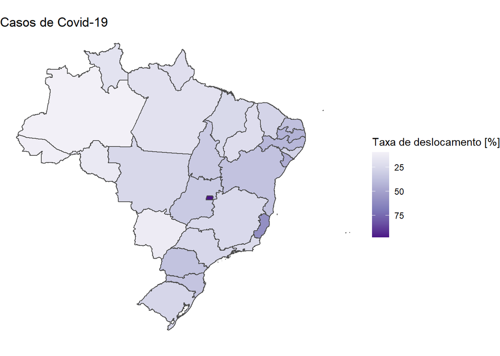

```r
#Covid-19
d1 <- dados_covid
estado <- sort(unique(d1$SG_UF_NOT))
valor <- data.table(prop.table(table(d1$SG_UF_NOT,d1$mudou_muni),1))
valor <- valor[valor$V2=="sim",]
dt1_estadual <- data.frame("uf"=valor$V1,"T1"=valor$N*100)
dt <- rbind(c("AC",12), c("AL",27), c("AP",16), c("AM",13), c("BA",29),
              c("CE",23), c("DF",53), c("ES",32), c("GO",52), c("MA",21),
              c("MT",51), c("MS",50), c("MG",31), c("PA",15), c("PB",25),
              c("PR",41), c("PE",26), c("PI",22), c("RN",24), c("RS",43),
              c("RJ",33), c("RO",11), c("RR",14), c("SC",42), c("SP",35),
              c("SE",28), c("TO",17)) %>% data.table %>% `colnames<-`(c("uf","id"))
mapaUF <- readRDS("mapaUF.Rds")
dt1 <- full_join(dt, dt1_estadual, by = "uf")
ggplot(dt1) + geom_map(map = mapaUF, color = 'gray30', aes_string(map_id = "id", fill = "T1")) + geom_path(data = mapaUF, color = 'gray30', size = .1, aes(x = long, y = lat, group = group)) + theme_void() + coord_equal() + labs(fill = "Taxa de deslocamento [%]",title="Casos de Covid-19") + scale_fill_distiller(palette="Purples",trans="reverse")
```

## H1N1

```r
#Se mudança de município para atendimento
dados_h1n1 <- dados_h1n1 %>%
  mutate(mudou_muni = case_when((ID_MN_RESI  == CO_MU_INTE) &
                                  !is.na(CO_MU_INTE) & !is.na(ID_MN_RESI) ~ "não",
                                (ID_MN_RESI != CO_MU_INTE) & !is.na(CO_MU_INTE) &
                                  !is.na(ID_MN_RESI) ~ "sim",
                                TRUE ~ NA_character_
                                )
  )
```

```r
#tabela cruzada
with(dados_h1n1, ctable(gestante_SN, mudou_muni, prop = "r", useNA = "no", chisq = TRUE, OR=TRUE))
```

```
## Cross-Tabulation, Row Proportions
## gestante_SN * mudou_muni
## Data Frame: dados_h1n1
##
##
## ------------- ------------ -------------- -------------- ---------------
##                 mudou_muni            não            sim           Total
##   gestante_SN
##           não                2946 (80.0%)    737 (20.0%)   3683 (100.0%)
##           sim                1710 (78.5%)    468 (21.5%)   2178 (100.0%)
##         Total                4656 (79.4%)   1205 (20.6%)   5861 (100.0%)
## ------------- ------------ -------------- -------------- ---------------
##
## ----------------------------
##  Chi.squared   df   p.value
## ------------- ---- ---------
##    1.7381      1    0.1874
## ----------------------------
##
## ----------------------------------
##  Odds Ratio   Lo - 95%   Hi - 95%
## ------------ ---------- ----------
##     1.09        0.96       1.25
## ----------------------------------
##
## --------------------------------
##  Risk Ratio   Lo - 0%   Hi - 0%
## ------------ --------- ---------
##     1.02       1.02      1.02
## --------------------------------
```

Iremos fazer um mapa para visualizar a taxa de pessoas que se deslocam para atendimento por estados :

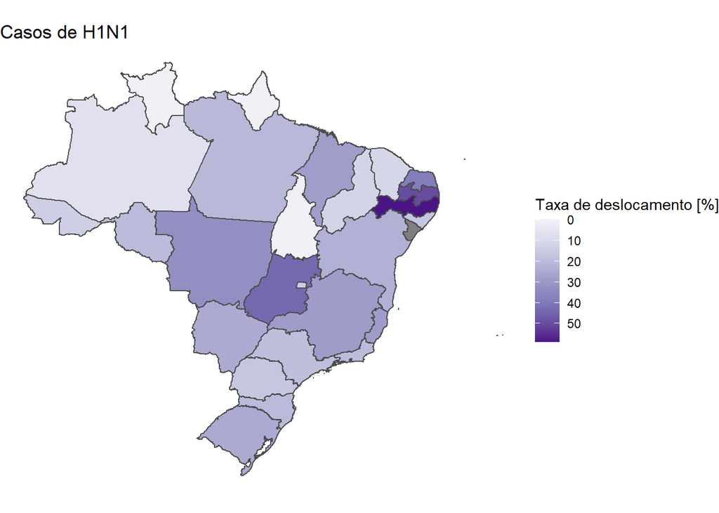

```r
#H1N1
d1 <- dados_h1n1
valor <- data.table(prop.table(table(d1$SG_UF_NOT,d1$mudou_muni),1))
valor <- valor[valor$V2=="sim",]
dt1_estadual <- data.frame("id"=valor$V1,"T1"=valor$N*100)
dt <- rbind(c("AC",12), c("AL",27), c("AP",16), c("AM",13), c("BA",29),
              c("CE",23), c("DF",53), c("ES",32), c("GO",52), c("MA",21),
              c("MT",51), c("MS",50), c("MG",31), c("PA",15), c("PB",25),
              c("PR",41), c("PE",26), c("PI",22), c("RN",24), c("RS",43),
              c("RJ",33), c("RO",11), c("RR",14), c("SC",42), c("SP",35),
              c("SE",28), c("TO",17)) %>% data.table %>% `colnames<-`(c("uf","id"))
mapaUF <- readRDS("mapaUF.Rds")
dt1 <- full_join(dt, dt1_estadual, by = "id")
ggplot(dt1) + geom_map(map = mapaUF, color = 'gray30', aes_string(map_id = "id", fill = "T1")) + geom_path(data = mapaUF, color = 'gray30', size = .1, aes(x = long, y = lat, group = group)) + theme_void() + coord_equal() + labs(fill = "Taxa de deslocamento [%]",title="Casos de H1N1") + scale_fill_distiller(palette="Purples",trans="reverse")
```

Agora iremos analisar os casos onde o paciente já foi vacinado ou não contra a gripe.

# Vacina

### H1N1

```r
#Se tomou vacina anti-gripal
dados_h1n1 <- dados_h1n1 %>%
  mutate(vacina = case_when(VACINA == 1 ~ "Sim",
                            VACINA == 2 ~ "Não",
                            TRUE ~ NA_character_)
         )
```

```r
#tabela cruzada
with(dados_h1n1, ctable(gestante_SN, vacina, prop = "r", useNA = "no", chisq = TRUE, OR=TRUE))
```

```
## Cross-Tabulation, Row Proportions
## gestante_SN * vacina
## Data Frame: dados_h1n1
##
##
## ------------- -------- -------------- ------------- ---------------
##                 vacina            Não           Sim           Total
##   gestante_SN
##           não            4475 (89.0%)   552 (11.0%)   5027 (100.0%)
##           sim            2069 (94.9%)   112 ( 5.1%)   2181 (100.0%)
##         Total            6544 (90.8%)   664 ( 9.2%)   7208 (100.0%)
## ------------- -------- -------------- ------------- ---------------
##
## ----------------------------
##  Chi.squared   df   p.value
## ------------- ---- ---------
##    61.4476     1       0
## ----------------------------
##
## ----------------------------------
##  Odds Ratio   Lo - 95%   Hi - 95%
## ------------ ---------- ----------
##     0.44        0.36       0.54
## ----------------------------------
##
## --------------------------------
##  Risk Ratio   Lo - 0%   Hi - 0%
## ------------ --------- ---------
##     0.94       0.94      0.94
## --------------------------------
```

### Covid-19

```r
#Se tomou vacina anti-gripal
dados_covid <- dados_covid %>%
  mutate(vacina = case_when(VACINA == 1 ~ "Sim",
                            VACINA == 2 ~ "Não",
                            TRUE ~ NA_character_)
         )
```

```r
#tabela cruzada
with(dados_covid, ctable(gestante_SN, vacina, prop = "r", useNA = "no", chisq = TRUE, OR=TRUE))
```

```
## Cross-Tabulation, Row Proportions
## gestante_SN * vacina
## Data Frame: dados_covid
##
##
## ------------- -------- --------------- -------------- ----------------
##                 vacina             Não            Sim            Total
##   gestante_SN
##           não            22984 (76.8%)   6930 (23.2%)   29914 (100.0%)
##           sim             1474 (63.1%)    861 (36.9%)    2335 (100.0%)
##         Total            24458 (75.8%)   7791 (24.2%)   32249 (100.0%)
## ------------- -------- --------------- -------------- ----------------
##
## ----------------------------
##  Chi.squared   df   p.value
## ------------- ---- ---------
##   221.3605     1       0
## ----------------------------
##
## ----------------------------------
##  Odds Ratio   Lo - 95%   Hi - 95%
## ------------ ---------- ----------
##     1.94        1.77       2.12
## ----------------------------------
##
## --------------------------------
##  Risk Ratio   Lo - 0%   Hi - 0%
## ------------ --------- ---------
##     1.22       1.22      1.22
## --------------------------------
```

# Sintomas

Agora iremos analisar as variáveis dos sintomas das bases de covid-19 e H1N1.

## Febre

### H1N1

```r
dados_h1n1 <-  dados_h1n1 %>%
  mutate(febre = case_when(FEBRE == 1 ~ "sim",
                              FEBRE == 2 ~ "não",
                              TRUE ~ NA_character_))
```

```r
#tabela cruzada
with(dados_h1n1, ctable(gestante_SN, febre, prop = "r", useNA = "no", chisq = TRUE, OR=TRUE))
```

```
## Cross-Tabulation, Row Proportions
## gestante_SN * febre
## Data Frame: dados_h1n1
##
##
## ------------- ------- ------------ -------------- ---------------
##                 febre          não            sim           Total
##   gestante_SN
##           não           208 (3.4%)   5861 (96.6%)   6069 (100.0%)
##           sim           170 (6.1%)   2595 (93.9%)   2765 (100.0%)
##         Total           378 (4.3%)   8456 (95.7%)   8834 (100.0%)
## ------------- ------- ------------ -------------- ---------------
##
## ----------------------------
##  Chi.squared   df   p.value
## ------------- ---- ---------
##    33.6772     1       0
## ----------------------------
##
## ----------------------------------
##  Odds Ratio   Lo - 95%   Hi - 95%
## ------------ ---------- ----------
##     0.54        0.44       0.67
## ----------------------------------
##
## --------------------------------
##  Risk Ratio   Lo - 0%   Hi - 0%
## ------------ --------- ---------
##     0.56       0.56      0.56
## --------------------------------
```

### COVID-19

```r
dados_covid <-  dados_covid %>%
  mutate(febre = case_when(FEBRE == 1 ~ "sim",
                              FEBRE == 2 ~ "não",
                              TRUE ~ NA_character_))
```

```r
#tabela cruzada
with(dados_covid, ctable(gestante_SN, febre, prop = "r", useNA = "no", chisq = TRUE, OR=TRUE))
```

```
## Cross-Tabulation, Row Proportions
## gestante_SN * febre
## Data Frame: dados_covid
##
##
## ------------- ------- --------------- --------------- ----------------
##                 febre             não             sim            Total
##   gestante_SN
##           não           15106 (27.2%)   40533 (72.8%)   55639 (100.0%)
##           sim            1290 (28.8%)    3187 (71.2%)    4477 (100.0%)
##         Total           16396 (27.3%)   43720 (72.7%)   60116 (100.0%)
## ------------- ------- --------------- --------------- ----------------
##
## ----------------------------
##  Chi.squared   df   p.value
## ------------- ---- ---------
##    5.7001      1     0.017
## ----------------------------
##
## ----------------------------------
##  Odds Ratio   Lo - 95%   Hi - 95%
## ------------ ---------- ----------
##     0.92        0.86       0.98
## ----------------------------------
##
## --------------------------------
##  Risk Ratio   Lo - 0%   Hi - 0%
## ------------ --------- ---------
##     0.94       0.94      0.94
## --------------------------------
```

## Tosse

### H1N1

```r
dados_h1n1 <-  dados_h1n1 %>%
  mutate(tosse = case_when(TOSSE == 1 ~ "sim",
                              TOSSE == 2 ~ "não",
                              TRUE ~ NA_character_))
```

```r
#tabela cruzada
with(dados_h1n1, ctable(gestante_SN, tosse, prop = "r", useNA = "no", chisq = TRUE, OR=TRUE))
```

```
## Cross-Tabulation, Row Proportions
## gestante_SN * tosse
## Data Frame: dados_h1n1
##
##
## ------------- ------- ------------ -------------- ---------------
##                 tosse          não            sim           Total
##   gestante_SN
##           não           228 (3.8%)   5837 (96.2%)   6065 (100.0%)
##           sim           107 (3.9%)   2658 (96.1%)   2765 (100.0%)
##         Total           335 (3.8%)   8495 (96.2%)   8830 (100.0%)
## ------------- ------- ------------ -------------- ---------------
##
## ----------------------------
##  Chi.squared   df   p.value
## ------------- ---- ---------
##    0.0369      1    0.8477
## ----------------------------
##
## ----------------------------------
##  Odds Ratio   Lo - 95%   Hi - 95%
## ------------ ---------- ----------
##     0.97        0.77       1.23
## ----------------------------------
##
## --------------------------------
##  Risk Ratio   Lo - 0%   Hi - 0%
## ------------ --------- ---------
##     0.97       0.97      0.97
## --------------------------------
```

### COVID-19

```r
dados_covid <-  dados_covid %>%
  mutate(tosse = case_when(TOSSE == 1 ~ "sim",
                              TOSSE == 2 ~ "não",
                              TRUE ~ NA_character_))
```

```r
#tabela cruzada
with(dados_covid, ctable(gestante_SN, tosse, prop = "r", useNA = "no", chisq = TRUE, OR=TRUE))
```

```
## Cross-Tabulation, Row Proportions
## gestante_SN * tosse
## Data Frame: dados_covid
##
##
## ------------- ------- --------------- --------------- ----------------
##                 tosse             não             sim            Total
##   gestante_SN
##           não           10327 (18.1%)   46729 (81.9%)   57056 (100.0%)
##           sim             850 (18.2%)    3810 (81.8%)    4660 (100.0%)
##         Total           11177 (18.1%)   50539 (81.9%)   61716 (100.0%)
## ------------- ------- --------------- --------------- ----------------
##
## ----------------------------
##  Chi.squared   df   p.value
## ------------- ---- ---------
##    0.0483      1     0.826
## ----------------------------
##
## ----------------------------------
##  Odds Ratio   Lo - 95%   Hi - 95%
## ------------ ---------- ----------
##     0.99        0.92       1.07
## ----------------------------------
##
## --------------------------------
##  Risk Ratio   Lo - 0%   Hi - 0%
## ------------ --------- ---------
##     0.99       0.99      0.99
## --------------------------------
```

## Dispneia

### H1N1

```r
dados_h1n1 <-  dados_h1n1 %>%
  mutate(dispneia = case_when(DISPNEIA == 1 ~ "sim",
                              DISPNEIA == 2 ~ "não",
                              TRUE ~ NA_character_))
```

```r
#tabela cruzada
with(dados_h1n1, ctable(gestante_SN, dispneia, prop = "r", useNA = "no", chisq = TRUE, OR=TRUE))
```

```
## Cross-Tabulation, Row Proportions
## gestante_SN * dispneia
## Data Frame: dados_h1n1
##
##
## ------------- ---------- -------------- -------------- ---------------
##                 dispneia            não            sim           Total
##   gestante_SN
##           não              1846 (31.0%)   4112 (69.0%)   5958 (100.0%)
##           sim               771 (28.4%)   1946 (71.6%)   2717 (100.0%)
##         Total              2617 (30.2%)   6058 (69.8%)   8675 (100.0%)
## ------------- ---------- -------------- -------------- ---------------
##
## ----------------------------
##  Chi.squared   df   p.value
## ------------- ---- ---------
##    5.8955      1    0.0152
## ----------------------------
##
## ----------------------------------
##  Odds Ratio   Lo - 95%   Hi - 95%
## ------------ ---------- ----------
##     1.13        1.03       1.25
## ----------------------------------
##
## --------------------------------
##  Risk Ratio   Lo - 0%   Hi - 0%
## ------------ --------- ---------
##     1.09       1.09      1.09
## --------------------------------
```

### COVID-19

```r
dados_covid <-  dados_covid %>%
  mutate(dispneia = case_when(DISPNEIA == 1 ~ "sim",
                              DISPNEIA == 2 ~ "não",
                              TRUE ~ NA_character_))
```

```r
#tabela cruzada
with(dados_covid, ctable(gestante_SN, dispneia, prop = "r", useNA = "no", chisq = TRUE, OR=TRUE))
```

```
## Cross-Tabulation, Row Proportions
## gestante_SN * dispneia
## Data Frame: dados_covid
##
##
## ------------- ---------- --------------- --------------- ----------------
##                 dispneia             não             sim            Total
##   gestante_SN
##           não              12210 (21.8%)   43792 (78.2%)   56002 (100.0%)
##           sim               1461 (32.6%)    3024 (67.4%)    4485 (100.0%)
##         Total              13671 (22.6%)   46816 (77.4%)   60487 (100.0%)
## ------------- ---------- --------------- --------------- ----------------
##
## ----------------------------
##  Chi.squared   df   p.value
## ------------- ---- ---------
##   274.8474     1       0
## ----------------------------
##
## ----------------------------------
##  Odds Ratio   Lo - 95%   Hi - 95%
## ------------ ---------- ----------
##     0.58        0.54       0.62
## ----------------------------------
##
## --------------------------------
##  Risk Ratio   Lo - 0%   Hi - 0%
## ------------ --------- ---------
##     0.67       0.67      0.67
## --------------------------------
```

## Dor de garganta

### H1N1

```r
dados_h1n1 <-  dados_h1n1 %>%
  mutate(garganta = case_when(GARGANTA == 1 ~ "sim",
                              GARGANTA  == 2 ~ "não",
                              TRUE ~ NA_character_))
```

```r
#tabela cruzada
with(dados_h1n1, ctable(gestante_SN, garganta, prop = "r", useNA = "no", chisq = TRUE, OR=TRUE))
```

```
## Cross-Tabulation, Row Proportions
## gestante_SN * garganta
## Data Frame: dados_h1n1
##
##
## ------------- ---------- -------------- -------------- ---------------
##                 garganta            não            sim           Total
##   gestante_SN
##           não              2559 (43.5%)   3323 (56.5%)   5882 (100.0%)
##           sim              1267 (47.8%)   1383 (52.2%)   2650 (100.0%)
##         Total              3826 (44.8%)   4706 (55.2%)   8532 (100.0%)
## ------------- ---------- -------------- -------------- ---------------
##
## ----------------------------
##  Chi.squared   df   p.value
## ------------- ---- ---------
##     13.52      1     2e-04
## ----------------------------
##
## ----------------------------------
##  Odds Ratio   Lo - 95%   Hi - 95%
## ------------ ---------- ----------
##     0.84        0.77       0.92
## ----------------------------------
##
## --------------------------------
##  Risk Ratio   Lo - 0%   Hi - 0%
## ------------ --------- ---------
##     0.91       0.91      0.91
## --------------------------------
```

### COVID-19

```r
dados_covid <-  dados_covid %>%
  mutate(garganta = case_when(GARGANTA == 1 ~ "sim",
                              GARGANTA  == 2 ~ "não",
                              TRUE ~ NA_character_))
```

```r
#tabela cruzada
with(dados_covid, ctable(gestante_SN, garganta, prop = "r", useNA = "no", chisq = TRUE, OR=TRUE))
```

```
## Cross-Tabulation, Row Proportions
## gestante_SN * garganta
## Data Frame: dados_covid
##
##
## ------------- ---------- --------------- --------------- ----------------
##                 garganta             não             sim            Total
##   gestante_SN
##           não              32266 (67.3%)   15665 (32.7%)   47931 (100.0%)
##           sim               2758 (70.4%)    1161 (29.6%)    3919 (100.0%)
##         Total              35024 (67.5%)   16826 (32.5%)   51850 (100.0%)
## ------------- ---------- --------------- --------------- ----------------
##
## ----------------------------
##  Chi.squared   df   p.value
## ------------- ---- ---------
##    15.3107     1     1e-04
## ----------------------------
##
## ----------------------------------
##  Odds Ratio   Lo - 95%   Hi - 95%
## ------------ ---------- ----------
##     0.87        0.81       0.93
## ----------------------------------
##
## --------------------------------
##  Risk Ratio   Lo - 0%   Hi - 0%
## ------------ --------- ---------
##     0.96       0.96      0.96
## --------------------------------
```

## Diarreia

### H1N1

```r
dados_h1n1 <-  dados_h1n1 %>%
  mutate(diarreia = case_when(DIARREIA == 1 ~ "sim",
                              DIARREIA == 2 ~ "não",
                              TRUE ~ NA_character_))
```

```r
#tabela cruzada
with(dados_h1n1, ctable(gestante_SN, diarreia, prop = "r", useNA = "no", chisq = TRUE, OR=TRUE))
```

```
## Cross-Tabulation, Row Proportions
## gestante_SN * diarreia
## Data Frame: dados_h1n1
##
##
## ------------- ---------- -------------- -------------- ---------------
##                 diarreia            não            sim           Total
##   gestante_SN
##           não              4894 (85.6%)    824 (14.4%)   5718 (100.0%)
##           sim              2310 (90.2%)    250 ( 9.8%)   2560 (100.0%)
##         Total              7204 (87.0%)   1074 (13.0%)   8278 (100.0%)
## ------------- ---------- -------------- -------------- ---------------
##
## ----------------------------
##  Chi.squared   df   p.value
## ------------- ---- ---------
##    33.3811     1       0
## ----------------------------
##
## ----------------------------------
##  Odds Ratio   Lo - 95%   Hi - 95%
## ------------ ---------- ----------
##     0.64        0.55       0.75
## ----------------------------------
##
## --------------------------------
##  Risk Ratio   Lo - 0%   Hi - 0%
## ------------ --------- ---------
##     0.95       0.95      0.95
## --------------------------------
```

### COVID-19

```r
dados_covid <-  dados_covid %>%
  mutate(diarreia = case_when(DIARREIA == 1 ~ "sim",
                              DIARREIA == 2 ~ "não",
                              TRUE ~ NA_character_))
```

```r
#tabela cruzada
with(dados_covid, ctable(gestante_SN, diarreia, prop = "r", useNA = "no", chisq = TRUE, OR=TRUE))
```

```
## Cross-Tabulation, Row Proportions
## gestante_SN * diarreia
## Data Frame: dados_covid
##
##
## ------------- ---------- --------------- --------------- ----------------
##                 diarreia             não             sim            Total
##   gestante_SN
##           não              35854 (76.8%)   10838 (23.2%)   46692 (100.0%)
##           sim               3211 (84.7%)     581 (15.3%)    3792 (100.0%)
##         Total              39065 (77.4%)   11419 (22.6%)   50484 (100.0%)
## ------------- ---------- --------------- --------------- ----------------
##
## ----------------------------
##  Chi.squared   df   p.value
## ------------- ---- ---------
##   124.2873     1       0
## ----------------------------
##
## ----------------------------------
##  Odds Ratio   Lo - 95%   Hi - 95%
## ------------ ---------- ----------
##     0.60        0.55       0.66
## ----------------------------------
##
## --------------------------------
##  Risk Ratio   Lo - 0%   Hi - 0%
## ------------ --------- ---------
##     0.91       0.91      0.91
## --------------------------------
```

## Saturação

### H1N1

*Obs : Não há casos com SATURAÇÃO preenchida, para a base de h1n1 só existem casos de NA*.

```r
dados_h1n1 <-  dados_h1n1 %>%
  mutate(saturacao = case_when(SATURACAO == 1 ~ "sim",
                              SATURACAO == 2 ~ "não",
                              TRUE ~ NA_character_))
```

```r
#tabela cruzada
#with(dados_h1n1, ctable(gestante_SN, saturacao, prop = "r", useNA = "no", chisq = TRUE, OR=TRUE))
```

### COVID-19

```r
dados_covid <-  dados_covid %>%
  mutate(saturacao = case_when(SATURACAO == 1 ~ "sim",
                              SATURACAO == 2 ~ "não",
                              TRUE ~ NA_character_))
```

```r
#tabela cruzada
with(dados_covid, ctable(gestante_SN, saturacao, prop = "r", useNA = "no", chisq = TRUE, OR=TRUE))
```

```
## Cross-Tabulation, Row Proportions
## gestante_SN * saturacao
## Data Frame: dados_covid
##
##
## ------------- ----------- --------------- --------------- ----------------
##                 saturacao             não             sim            Total
##   gestante_SN
##           não               19724 (37.9%)   32338 (62.1%)   52062 (100.0%)
##           sim                2405 (58.2%)    1730 (41.8%)    4135 (100.0%)
##         Total               22129 (39.4%)   34068 (60.6%)   56197 (100.0%)
## ------------- ----------- --------------- --------------- ----------------
##
## ----------------------------
##  Chi.squared   df   p.value
## ------------- ---- ---------
##   658.9082     1       0
## ----------------------------
##
## ----------------------------------
##  Odds Ratio   Lo - 95%   Hi - 95%
## ------------ ---------- ----------
##     0.44        0.41       0.47
## ----------------------------------
##
## --------------------------------
##  Risk Ratio   Lo - 0%   Hi - 0%
## ------------ --------- ---------
##     0.65       0.65      0.65
## --------------------------------
```

# Comorbidades

Iremos analisar as variáveis de comorbidades para as duas pandemias. Sendo essas: Cardiopatia, pneumopatia, renal, imunodepressão, hematologia e diabetes.

Para fazermos essa análise iremos organizar e rotular todas essas variáveis referentes as comorbidades.

```r
## Base H1N1

dados_h1n1 <- dados_h1n1 %>%
  mutate(cardiopati = case_when(CARDIOPATI == 1 ~ "Sim",
                                CARDIOPATI == 2 ~ "Não",
                                TRUE ~ NA_character_))

dados_h1n1 <- dados_h1n1 %>%
  mutate(pneumopati = case_when(PNEUMOPATI == 1 ~ "Sim",
                                PNEUMOPATI == 2 ~ "Não",
                                TRUE ~ NA_character_))

dados_h1n1 <- dados_h1n1 %>%
  mutate(renal = case_when(RENAL == 1 ~ "Sim",
                           RENAL == 2 ~ "Não",
                           TRUE ~ NA_character_))

dados_h1n1 <- dados_h1n1 %>%
  mutate(imunodepre = case_when(IMUNODEPRE == 1 ~ "Sim",
                                IMUNODEPRE == 2 ~ "Não",
                                TRUE ~ NA_character_))
dados_h1n1 <- dados_h1n1 %>%
  mutate(hematologi = case_when(HEMOGLOBI == 1 ~ "Sim",
                                HEMOGLOBI == 2 ~ "Não",
                                TRUE ~ NA_character_))

dados_h1n1 <- dados_h1n1 %>%
  mutate(diabetes = case_when(METABOLICA == 1 ~ "Sim",
                              METABOLICA == 2 ~ "Não",
                              TRUE ~ NA_character_))

# Base do COVID

dados_covid <- dados_covid %>%
  mutate(cardiopati = case_when(CARDIOPATI == 1 ~ "Sim",
                                CARDIOPATI == 2 ~ "Não",
                                TRUE ~ NA_character_))

dados_covid <- dados_covid %>%
  mutate(pneumopati = case_when((PNEUMOPATI == 1 | ASMA == 1) ~ "Sim",
                                (PNEUMOPATI == 2 | ASMA == 2) ~ "Não",
                                TRUE ~ NA_character_))

dados_covid <- dados_covid %>%
  mutate(renal = case_when(RENAL == 1 ~ "Sim",
                           RENAL == 2 ~ "Não",
                           TRUE ~ NA_character_))

dados_covid <- dados_covid %>%
  mutate(imunodepre = case_when(IMUNODEPRE == 1 ~ "Sim",
                                IMUNODEPRE == 2 ~ "Não",
                                TRUE ~ NA_character_))

dados_covid <- dados_covid %>%
  mutate(hematologi = case_when(HEMATOLOGI == 1 ~ "Sim",
                                HEMATOLOGI == 2 ~ "Não",
                                TRUE ~ NA_character_))

dados_covid <- dados_covid %>%
  mutate(diabetes = case_when(DIABETES == 1 ~ "Sim",
                              DIABETES == 2 ~ "Não",
                              TRUE ~ NA_character_))
```

Com nossa base já estruturada, iremos fazer uma breve análise dessas variáveis.

## Cardiopatia

### H1N1:

```r
#tabela cruzada
with(dados_h1n1, ctable(gestante_SN, cardiopati, prop = "r", useNA = "no", chisq = TRUE, OR=TRUE))
```

```
## Cross-Tabulation, Row Proportions
## gestante_SN * cardiopati
## Data Frame: dados_h1n1
##
##
## ------------- ------------ -------------- ------------ ---------------
##                 cardiopati            Não          Sim           Total
##   gestante_SN
##           não                5459 (97.1%)   165 (2.9%)   5624 (100.0%)
##           sim                2440 (98.5%)    38 (1.5%)   2478 (100.0%)
##         Total                7899 (97.5%)   203 (2.5%)   8102 (100.0%)
## ------------- ------------ -------------- ------------ ---------------
##
## ----------------------------
##  Chi.squared   df   p.value
## ------------- ---- ---------
##    13.2413     1     3e-04
## ----------------------------
##
## ----------------------------------
##  Odds Ratio   Lo - 95%   Hi - 95%
## ------------ ---------- ----------
##     0.52        0.36       0.74
## ----------------------------------
##
## --------------------------------
##  Risk Ratio   Lo - 0%   Hi - 0%
## ------------ --------- ---------
##     0.99       0.99      0.99
## --------------------------------
```

### COVID-19:

```r
#tabela cruzada
with(dados_covid, ctable(gestante_SN, cardiopati, prop = "r", useNA = "no", chisq = TRUE, OR=TRUE))
```

```
## Cross-Tabulation, Row Proportions
## gestante_SN * cardiopati
## Data Frame: dados_covid
##
##
## ------------- ------------ --------------- -------------- ----------------
##                 cardiopati             Não            Sim            Total
##   gestante_SN
##           não                12854 (57.1%)   9644 (42.9%)   22498 (100.0%)
##           sim                 1346 (81.1%)    314 (18.9%)    1660 (100.0%)
##         Total                14200 (58.8%)   9958 (41.2%)   24158 (100.0%)
## ------------- ------------ --------------- -------------- ----------------
##
## ----------------------------
##  Chi.squared   df   p.value
## ------------- ---- ---------
##   365.0087     1       0
## ----------------------------
##
## ----------------------------------
##  Odds Ratio   Lo - 95%   Hi - 95%
## ------------ ---------- ----------
##     0.31        0.27       0.35
## ----------------------------------
##
## --------------------------------
##  Risk Ratio   Lo - 0%   Hi - 0%
## ------------ --------- ---------
##     0.70       0.70      0.70
## --------------------------------
```

## Pneumopatia

### H1N1:

```r
#tabela cruzada
with(dados_h1n1, ctable(gestante_SN, pneumopati, prop = "r", useNA = "no", chisq = FALSE, OR=TRUE))
```

```
## Cross-Tabulation, Row Proportions
## gestante_SN * pneumopati
## Data Frame: dados_h1n1
##
##
## ------------- ------------ -------------- ------------ ---------------
##                 pneumopati            Não          Sim           Total
##   gestante_SN
##           não                5210 (92.5%)   425 (7.5%)   5635 (100.0%)
##           sim                2353 (95.3%)   117 (4.7%)   2470 (100.0%)
##         Total                7563 (93.3%)   542 (6.7%)   8105 (100.0%)
## ------------- ------------ -------------- ------------ ---------------
##
## ----------------------------------
##  Odds Ratio   Lo - 95%   Hi - 95%
## ------------ ---------- ----------
##     0.61        0.49       0.75
## ----------------------------------
##
## --------------------------------
##  Risk Ratio   Lo - 0%   Hi - 0%
## ------------ --------- ---------
##     0.97       0.97      0.97
## --------------------------------
```

### COVID-19:

```r
#tabela cruzada
with(dados_covid, ctable(gestante_SN, pneumopati, prop = "r", useNA = "no", chisq = TRUE, OR=TRUE))
```

```
## Cross-Tabulation, Row Proportions
## gestante_SN * pneumopati
## Data Frame: dados_covid
##
##
## ------------- ------------ --------------- -------------- ----------------
##                 pneumopati             Não            Sim            Total
##   gestante_SN
##           não                16658 (81.8%)   3694 (18.2%)   20352 (100.0%)
##           sim                 1421 (86.3%)    226 (13.7%)    1647 (100.0%)
##         Total                18079 (82.2%)   3920 (17.8%)   21999 (100.0%)
## ------------- ------------ --------------- -------------- ----------------
##
## ----------------------------
##  Chi.squared   df   p.value
## ------------- ---- ---------
##    20.1058     1       0
## ----------------------------
##
## ----------------------------------
##  Odds Ratio   Lo - 95%   Hi - 95%
## ------------ ---------- ----------
##     0.72        0.62       0.83
## ----------------------------------
##
## --------------------------------
##  Risk Ratio   Lo - 0%   Hi - 0%
## ------------ --------- ---------
##     0.95       0.95      0.95
## --------------------------------
```

## Renal

### H1N1:

```r
#tabela cruzada
with(dados_h1n1, ctable(gestante_SN, renal, prop = "r", useNA = "no", chisq = FALSE, OR=TRUE))
```

```
## Cross-Tabulation, Row Proportions
## gestante_SN * renal
## Data Frame: dados_h1n1
##
##
## ------------- ------- --------------- ----------- ---------------
##                 renal             Não         Sim           Total
##   gestante_SN
##           não           5554 ( 98.8%)   66 (1.2%)   5620 (100.0%)
##           sim           2464 ( 99.6%)   10 (0.4%)   2474 (100.0%)
##         Total           8018 ( 99.1%)   76 (0.9%)   8094 (100.0%)
## ------------- ------- --------------- ----------- ---------------
##
## ----------------------------------
##  Odds Ratio   Lo - 95%   Hi - 95%
## ------------ ---------- ----------
##     0.34        0.18       0.67
## ----------------------------------
##
## --------------------------------
##  Risk Ratio   Lo - 0%   Hi - 0%
## ------------ --------- ---------
##     0.99       0.99      0.99
## --------------------------------
```

Como existem caselas muito proximas de 5 iremos fazer um teste exato de Fisher

```r
#teste exato de Fisher
fisher.test(dados_h1n1$renal, dados_h1n1$gestante_SN)
```

```
##
##  Fisher's Exact Test for Count Data
##
## data:  dados_h1n1$renal and dados_h1n1$gestante_SN
## p-value = 0.0006227
## alternative hypothesis: true odds ratio is not equal to 1
## 95 percent confidence interval:
##  0.1562990 0.6698897
## sample estimates:
## odds ratio
##  0.3415641
```

### COVID-19:

```r
#tabela cruzada
with(dados_covid, ctable(gestante_SN, renal, prop = "r", useNA = "no", chisq = TRUE, OR=TRUE))
```

```
## Cross-Tabulation, Row Proportions
## gestante_SN * renal
## Data Frame: dados_covid
##
##
## ------------- ------- --------------- ------------- ----------------
##                 renal             Não           Sim            Total
##   gestante_SN
##           não           17886 (92.2%)   1519 (7.8%)   19405 (100.0%)
##           sim            1535 (98.0%)     31 (2.0%)    1566 (100.0%)
##         Total           19421 (92.6%)   1550 (7.4%)   20971 (100.0%)
## ------------- ------- --------------- ------------- ----------------
##
## ----------------------------
##  Chi.squared   df   p.value
## ------------- ---- ---------
##    71.5554     1       0
## ----------------------------
##
## ----------------------------------
##  Odds Ratio   Lo - 95%   Hi - 95%
## ------------ ---------- ----------
##     0.24        0.17       0.34
## ----------------------------------
##
## --------------------------------
##  Risk Ratio   Lo - 0%   Hi - 0%
## ------------ --------- ---------
##     0.94       0.94      0.94
## --------------------------------
```

## Imunodepressão

### H1N1:

```r
#tabela cruzada
with(dados_h1n1, ctable(gestante_SN, imunodepre, prop = "r", useNA = "no", chisq = TRUE, OR=TRUE))
```

```
## Cross-Tabulation, Row Proportions
## gestante_SN * imunodepre
## Data Frame: dados_h1n1
##
##
## ------------- ------------ -------------- ------------ ---------------
##                 imunodepre            Não          Sim           Total
##   gestante_SN
##           não                5444 (96.8%)   179 (3.2%)   5623 (100.0%)
##           sim                2432 (98.1%)    46 (1.9%)   2478 (100.0%)
##         Total                7876 (97.2%)   225 (2.8%)   8101 (100.0%)
## ------------- ------------ -------------- ------------ ---------------
##
## ----------------------------
##  Chi.squared   df   p.value
## ------------- ---- ---------
##    10.7309     1    0.0011
## ----------------------------
##
## ----------------------------------
##  Odds Ratio   Lo - 95%   Hi - 95%
## ------------ ---------- ----------
##     0.58        0.41       0.80
## ----------------------------------
##
## --------------------------------
##  Risk Ratio   Lo - 0%   Hi - 0%
## ------------ --------- ---------
##     0.99       0.99      0.99
## --------------------------------
```

### COVID-19:

```r
#tabela cruzada
with(dados_covid, ctable(gestante_SN, imunodepre, prop = "r", useNA = "no", chisq = TRUE, OR=TRUE))
```

```
## Cross-Tabulation, Row Proportions
## gestante_SN * imunodepre
## Data Frame: dados_covid
##
##
## ------------- ------------ --------------- ------------- ----------------
##                 imunodepre             Não           Sim            Total
##   gestante_SN
##           não                17742 (90.8%)   1806 (9.2%)   19548 (100.0%)
##           sim                 1523 (96.8%)     50 (3.2%)    1573 (100.0%)
##         Total                19265 (91.2%)   1856 (8.8%)   21121 (100.0%)
## ------------- ------------ --------------- ------------- ----------------
##
## ----------------------------
##  Chi.squared   df   p.value
## ------------- ---- ---------
##    65.9523     1       0
## ----------------------------
##
## ----------------------------------
##  Odds Ratio   Lo - 95%   Hi - 95%
## ------------ ---------- ----------
##     0.32        0.24       0.43
## ----------------------------------
##
## --------------------------------
##  Risk Ratio   Lo - 0%   Hi - 0%
## ------------ --------- ---------
##     0.94       0.94      0.94
## --------------------------------
```

## Hematologia

### H1N1:

```r
#tabela cruzada
with(dados_h1n1, ctable(gestante_SN, hematologi, prop = "r", useNA = "no", chisq = TRUE, OR=TRUE))
```

```
## Cross-Tabulation, Row Proportions
## gestante_SN * hematologi
## Data Frame: dados_h1n1
##
##
## ------------- ------------ --------------- ----------- ---------------
##                 hematologi             Não         Sim           Total
##   gestante_SN
##           não                5589 ( 99.5%)   28 (0.5%)   5617 (100.0%)
##           sim                2455 ( 99.4%)   14 (0.6%)   2469 (100.0%)
##         Total                8044 ( 99.5%)   42 (0.5%)   8086 (100.0%)
## ------------- ------------ --------------- ----------- ---------------
##
## ----------------------------
##  Chi.squared   df   p.value
## ------------- ---- ---------
##    0.0515      1    0.8205
## ----------------------------
##
## ----------------------------------
##  Odds Ratio   Lo - 95%   Hi - 95%
## ------------ ---------- ----------
##     1.14        0.60       2.17
## ----------------------------------
##
## --------------------------------
##  Risk Ratio   Lo - 0%   Hi - 0%
## ------------ --------- ---------
##     1.00       1.00      1.00
## --------------------------------
```

### COVID-19:

```r
#tabela cruzada
with(dados_covid, ctable(gestante_SN, hematologi, prop = "r", useNA = "no", chisq = TRUE, OR=TRUE))
```

```
## Cross-Tabulation, Row Proportions
## gestante_SN * hematologi
## Data Frame: dados_covid
##
##
## ------------- ------------ --------------- ------------ ----------------
##                 hematologi             Não          Sim            Total
##   gestante_SN
##           não                18689 (97.2%)   535 (2.8%)   19224 (100.0%)
##           sim                 1551 (98.5%)    24 (1.5%)    1575 (100.0%)
##         Total                20240 (97.3%)   559 (2.7%)   20799 (100.0%)
## ------------- ------------ --------------- ------------ ----------------
##
## ----------------------------
##  Chi.squared   df   p.value
## ------------- ---- ---------
##    8.3501      1    0.0039
## ----------------------------
##
## ----------------------------------
##  Odds Ratio   Lo - 95%   Hi - 95%
## ------------ ---------- ----------
##     0.54        0.36       0.82
## ----------------------------------
##
## --------------------------------
##  Risk Ratio   Lo - 0%   Hi - 0%
## ------------ --------- ---------
##     0.99       0.99      0.99
## --------------------------------
```

## Diabetes

### H1N1

```r
#tabela cruzada
with(dados_h1n1, ctable(gestante_SN, diabetes, prop = "r", useNA = "no", chisq = TRUE, OR=TRUE))
```

```
## Cross-Tabulation, Row Proportions
## gestante_SN * diabetes
## Data Frame: dados_h1n1
##
##
## ------------- ---------- -------------- ------------ ---------------
##                 diabetes            Não          Sim           Total
##   gestante_SN
##           não              5467 (97.4%)   147 (2.6%)   5614 (100.0%)
##           sim              2451 (99.3%)    18 (0.7%)   2469 (100.0%)
##         Total              7918 (98.0%)   165 (2.0%)   8083 (100.0%)
## ------------- ---------- -------------- ------------ ---------------
##
## ----------------------------
##  Chi.squared   df   p.value
## ------------- ---- ---------
##    29.6765     1       0
## ----------------------------
##
## ----------------------------------
##  Odds Ratio   Lo - 95%   Hi - 95%
## ------------ ---------- ----------
##     0.27        0.17       0.45
## ----------------------------------
##
## --------------------------------
##  Risk Ratio   Lo - 0%   Hi - 0%
## ------------ --------- ---------
##     0.98       0.98      0.98
## --------------------------------
```

### COVID-19:

```r
#tabela cruzada
with(dados_covid, ctable(gestante_SN, diabetes, prop = "r", useNA = "no", chisq = TRUE, OR=TRUE))
```

```
## Cross-Tabulation, Row Proportions
## gestante_SN * diabetes
## Data Frame: dados_covid
##
##
## ------------- ---------- --------------- -------------- ----------------
##                 diabetes             Não            Sim            Total
##   gestante_SN
##           não              14112 (65.1%)   7560 (34.9%)   21672 (100.0%)
##           sim               1305 (76.7%)    397 (23.3%)    1702 (100.0%)
##         Total              15417 (66.0%)   7957 (34.0%)   23374 (100.0%)
## ------------- ---------- --------------- -------------- ----------------
##
## ----------------------------
##  Chi.squared   df   p.value
## ------------- ---- ---------
##    93.377      1       0
## ----------------------------
##
## ----------------------------------
##  Odds Ratio   Lo - 95%   Hi - 95%
## ------------ ---------- ----------
##     0.57        0.51       0.64
## ----------------------------------
##
## --------------------------------
##  Risk Ratio   Lo - 0%   Hi - 0%
## ------------ --------- ---------
##     0.85       0.85      0.85
## --------------------------------
```

# Desfecho

Será analisada a variável que informa o desfecho do caso, sendo esses: Cura ou óbito.

### H1N1

```r
with(dados_h1n1, ctable(gestante_SN, evolucao, prop="r", OR=TRUE, useNA = "no", chisq = TRUE))
```

```
## Cross-Tabulation, Row Proportions
## gestante_SN * evolucao
## Data Frame: dados_h1n1
##
##
## ------------- ---------- -------------- ------------ ---------------
##                 evolucao           cura        obito           Total
##   gestante_SN
##           não              5151 (91.9%)   453 (8.1%)   5604 (100.0%)
##           sim              2349 (92.1%)   201 (7.9%)   2550 (100.0%)
##         Total              7500 (92.0%)   654 (8.0%)   8154 (100.0%)
## ------------- ---------- -------------- ------------ ---------------
##
## ----------------------------
##  Chi.squared   df   p.value
## ------------- ---- ---------
##    0.0708      1    0.7902
## ----------------------------
##
## ----------------------------------
##  Odds Ratio   Lo - 95%   Hi - 95%
## ------------ ---------- ----------
##     0.97        0.82       1.16
## ----------------------------------
##
## --------------------------------
##  Risk Ratio   Lo - 0%   Hi - 0%
## ------------ --------- ---------
##     1.00       1.00      1.00
## --------------------------------
```

### COVID-19

```r
with(dados_covid, ctable(gestante_SN, evolucao, prop="r", OR=TRUE, useNA = "no", chisq = TRUE))
```

```
## Cross-Tabulation, Row Proportions
## gestante_SN * evolucao
## Data Frame: dados_covid
##
##
## ------------- ---------- --------------- -------------- ----------------
##                 evolucao            cura          obito            Total
##   gestante_SN
##           não              46135 (83.0%)   9447 (17.0%)   55582 (100.0%)
##           sim               4011 (89.9%)    449 (10.1%)    4460 (100.0%)
##         Total              50146 (83.5%)   9896 (16.5%)   60042 (100.0%)
## ------------- ---------- --------------- -------------- ----------------
##
## ----------------------------
##  Chi.squared   df   p.value
## ------------- ---- ---------
##   143.5095     1       0
## ----------------------------
##
## ----------------------------------
##  Odds Ratio   Lo - 95%   Hi - 95%
## ------------ ---------- ----------
##     0.55        0.49       0.60
## ----------------------------------
##
## --------------------------------
##  Risk Ratio   Lo - 0%   Hi - 0%
## ------------ --------- ---------
##     0.92       0.92      0.92
## --------------------------------
```

# Critério de Gravidade

Iremo analisar agora, a gravidade dos casos. Para isso, foi levado em consideração casos graves aqueles que houveram internação, e casos menos graves aqueles os quais não houveram internação.

Como ponto inicial, criamos uma variável de gravidade.

```r
# PARA a base do H1N1
dados_h1n1 <- dados_h1n1 %>%
  mutate(gravidade = factor(case_when(HOSPITAL == 1 ~ "internou",
                               HOSPITAL == 2 ~ "não internou",
                              TRUE ~ NA_character_)))
dados_h1n1$gravidade <- relevel(
  dados_h1n1$gravidade,
  ref = "não internou"
)
# PARA a base do COVID
dados_covid <- dados_covid %>%
  mutate(gravidade = factor(case_when(HOSPITAL == 1 ~ "internou",
                               HOSPITAL == 2 ~ "não internou",
                               TRUE ~ NA_character_)))
dados_covid$gravidade <- relevel(
  dados_covid$gravidade,
  ref = "não internou"
)
```

Agora, iremos analisar a taxa de casos com internação e não internação

### H1N1

```r
#tabela cruzada
with(dados_h1n1, ctable(gestante_SN, gravidade, prop = "r", useNA = "no", chisq = TRUE, OR=TRUE))
```

```
## Cross-Tabulation, Row Proportions
## gestante_SN * gravidade
## Data Frame: dados_h1n1
##
##
## ------------- ----------- -------------- -------------- ---------------
##                 gravidade   não internou       internou           Total
##   gestante_SN
##           não               2173 (36.9%)   3714 (63.1%)   5887 (100.0%)
##           sim                533 (19.6%)   2191 (80.4%)   2724 (100.0%)
##         Total               2706 (31.4%)   5905 (68.6%)   8611 (100.0%)
## ------------- ----------- -------------- -------------- ---------------
##
## ----------------------------
##  Chi.squared   df   p.value
## ------------- ---- ---------
##   259.1859     1       0
## ----------------------------
##
## ----------------------------------
##  Odds Ratio   Lo - 95%   Hi - 95%
## ------------ ---------- ----------
##     2.41        2.16       2.68
## ----------------------------------
##
## --------------------------------
##  Risk Ratio   Lo - 0%   Hi - 0%
## ------------ --------- ---------
##     1.89       1.89      1.89
## --------------------------------
```

### COVID-19

```r
#tabela cruzada
with(dados_covid, ctable(gestante_SN, gravidade, prop = "r", useNA = "no", chisq = TRUE, OR=TRUE))
```

```
## Cross-Tabulation, Row Proportions
## gestante_SN * gravidade
## Data Frame: dados_covid
##
##
## ------------- ----------- -------------- --------------- ----------------
##                 gravidade   não internou        internou            Total
##   gestante_SN
##           não                3145 (5.2%)   57888 (94.8%)   61033 (100.0%)
##           sim                 151 (3.0%)    4836 (97.0%)    4987 (100.0%)
##         Total                3296 (5.0%)   62724 (95.0%)   66020 (100.0%)
## ------------- ----------- -------------- --------------- ----------------
##
## ----------------------------
##  Chi.squared   df   p.value
## ------------- ---- ---------
##    43.4474     1       0
## ----------------------------
##
## ----------------------------------
##  Odds Ratio   Lo - 95%   Hi - 95%
## ------------ ---------- ----------
##     1.74        1.47       2.05
## ----------------------------------
##
## --------------------------------
##  Risk Ratio   Lo - 0%   Hi - 0%
## ------------ --------- ---------
##     1.70       1.70      1.70
## --------------------------------
```

# Casos apenas de gestantes nas duas pandemias (2º Artigo)

Nessa seção serão analisados apenas os casos de mulheres gestantes nas duas pandemias. Para isso criamos uma coluna que indica de qual pandemia se trata aquele caso (H1N1 ou Covid-19).

```r
dados_covid <- dados_covid %>%
  mutate(pandemia = case_when(gestante_SN == "sim" ~ "Covid-19",
                              TRUE ~ NA_character_))
dados_h1n1 <- dados_h1n1 %>%
  mutate(pandemia = case_when(gestante_SN == "sim" ~ "H1N1",
                              TRUE ~ NA_character_))

df1 <- dados_covid %>%
  select(faixa_et,gestante_SN,raca,vacina,febre,tosse,dispneia,diarreia,garganta,pandemia,cardiopati,pneumopati,renal,imunodepre,hematologi,diabetes,gravidade,evolucao) %>%
  filter(gestante_SN=="sim")

df2 <- dados_h1n1 %>%
  select(faixa_et,gestante_SN,raca,vacina,febre,tosse,dispneia,diarreia,garganta,pandemia,cardiopati,pneumopati,renal,imunodepre,hematologi,diabetes,gravidade,evolucao) %>%
  filter(gestante_SN=="sim")

dados <- full_join(df1, df2)
```

## Idade (Faixa Etária)

```r
#tabela cruzada
with(dados, ctable(faixa_et, pandemia, prop = "r", useNA = "no", chisq = TRUE))
```

```
## Cross-Tabulation, Row Proportions
## faixa_et * pandemia
## Data Frame: dados
##
##
## ---------- ---------- -------------- -------------- ---------------
##              pandemia       Covid-19           H1N1           Total
##   faixa_et
##        <20               308 (38.0%)    503 (62.0%)    811 (100.0%)
##      20-34              3328 (61.9%)   2046 (38.1%)   5374 (100.0%)
##       >=35              1406 (85.8%)    233 (14.2%)   1639 (100.0%)
##      Total              5042 (64.4%)   2782 (35.6%)   7824 (100.0%)
## ---------- ---------- -------------- -------------- ---------------
##
## ----------------------------
##  Chi.squared   df   p.value
## ------------- ---- ---------
##   588.4991     2       0
## ----------------------------
```

## Raça

```r
#tabela cruzada
with(dados, ctable(raca, pandemia,prop = "r", useNA = "no",chisq = FALSE))
```

```
## Cross-Tabulation, Row Proportions
## raca * pandemia
## Data Frame: dados
##
## ---------- ---------- -------------- -------------- ---------------
##              pandemia       Covid-19           H1N1           Total
##       raca
##    Amarela                50 (74.6%)     17 (25.4%)     67 (100.0%)
##     Branca              1808 (51.9%)   1674 (48.1%)   3482 (100.0%)
##   Indigena                14 (70.0%)      6 (30.0%)     20 (100.0%)
##      Parda              1981 (76.1%)    623 (23.9%)   2604 (100.0%)
##      Preta               278 (61.2%)    176 (38.8%)    454 (100.0%)
##      Total              4131 (62.3%)   2496 (37.7%)   6627 (100.0%)
## ---------- ---------- -------------- -------------- ---------------
```

```r
#teste exato de Fisher
fisher.test(dados$raca, dados$pandemia,simulate.p.value = TRUE)
```

```
##
##  Fisher's Exact Test for Count Data with simulated p-value (based on
##  2000 replicates)
##
## data:  dados$raca and dados$pandemia
## p-value = 0.0004998
## alternative hypothesis: two.sided
```

## Vacina

```r
#tabela cruzada
with(dados, ctable(pandemia, vacina, prop = "r", useNA = "no", chisq = TRUE, OR=TRUE))
```

```
## Cross-Tabulation, Row Proportions
## pandemia * vacina
## Data Frame: dados
##
##
## ---------- -------- -------------- ------------- ---------------
##              vacina            Não           Sim           Total
##   pandemia
##   Covid-19            1474 (63.1%)   861 (36.9%)   2335 (100.0%)
##       H1N1            2069 (94.9%)   112 ( 5.1%)   2181 (100.0%)
##      Total            3543 (78.5%)   973 (21.5%)   4516 (100.0%)
## ---------- -------- -------------- ------------- ---------------
##
## ----------------------------
##  Chi.squared   df   p.value
## ------------- ---- ---------
##   670.1443     1       0
## ----------------------------
##
## ----------------------------------
##  Odds Ratio   Lo - 95%   Hi - 95%
## ------------ ---------- ----------
##    0.093       0.075      0.114
## ----------------------------------
##
## --------------------------------
##  Risk Ratio   Lo - 0%   Hi - 0%
## ------------ --------- ---------
##     0.67       0.67      0.67
## --------------------------------
```

## Febre

```r
#tabela cruzada
with(dados, ctable(pandemia, febre, prop = "r", useNA = "no", chisq = TRUE, OR=TRUE))
```

```
## Cross-Tabulation, Row Proportions
## pandemia * febre
## Data Frame: dados
##
##
## ---------- ------- -------------- -------------- ---------------
##              febre            não            sim           Total
##   pandemia
##   Covid-19           1290 (28.8%)   3187 (71.2%)   4477 (100.0%)
##       H1N1            170 ( 6.1%)   2595 (93.9%)   2765 (100.0%)
##      Total           1460 (20.2%)   5782 (79.8%)   7242 (100.0%)
## ---------- ------- -------------- -------------- ---------------
##
## ----------------------------
##  Chi.squared   df   p.value
## ------------- ---- ---------
##   544.1576     1       0
## ----------------------------
##
## ----------------------------------
##  Odds Ratio   Lo - 95%   Hi - 95%
## ------------ ---------- ----------
##     6.18        5.22       7.31
## ----------------------------------
##
## --------------------------------
##  Risk Ratio   Lo - 0%   Hi - 0%
## ------------ --------- ---------
##     4.69       4.69      4.69
## --------------------------------
```

## Tosse

```r
#tabela cruzada
with(dados, ctable(pandemia, tosse, prop = "r", useNA = "no", chisq = TRUE, OR=TRUE))
```

```
## Cross-Tabulation, Row Proportions
## pandemia * tosse
## Data Frame: dados
##
##
## ---------- ------- ------------- -------------- ---------------
##              tosse           não            sim           Total
##   pandemia
##   Covid-19           850 (18.2%)   3810 (81.8%)   4660 (100.0%)
##       H1N1           107 ( 3.9%)   2658 (96.1%)   2765 (100.0%)
##      Total           957 (12.9%)   6468 (87.1%)   7425 (100.0%)
## ---------- ------- ------------- -------------- ---------------
##
## ----------------------------
##  Chi.squared   df   p.value
## ------------- ---- ---------
##   317.9059     1       0
## ----------------------------
##
## ----------------------------------
##  Odds Ratio   Lo - 95%   Hi - 95%
## ------------ ---------- ----------
##     5.54        4.51       6.82
## ----------------------------------
##
## --------------------------------
##  Risk Ratio   Lo - 0%   Hi - 0%
## ------------ --------- ---------
##     4.71       4.71      4.71
## --------------------------------
```

## Dispneia

```r
#tabela cruzada
with(dados, ctable(pandemia, dispneia, prop = "r", useNA = "no", chisq = TRUE, OR=TRUE))
```

```
## Cross-Tabulation, Row Proportions
## pandemia * dispneia
## Data Frame: dados
##
##
## ---------- ---------- -------------- -------------- ---------------
##              dispneia            não            sim           Total
##   pandemia
##   Covid-19              1461 (32.6%)   3024 (67.4%)   4485 (100.0%)
##       H1N1               771 (28.4%)   1946 (71.6%)   2717 (100.0%)
##      Total              2232 (31.0%)   4970 (69.0%)   7202 (100.0%)
## ---------- ---------- -------------- -------------- ---------------
##
## ----------------------------
##  Chi.squared   df   p.value
## ------------- ---- ---------
##    13.7493     1     2e-04
## ----------------------------
##
## ----------------------------------
##  Odds Ratio   Lo - 95%   Hi - 95%
## ------------ ---------- ----------
##     1.22        1.10       1.35
## ----------------------------------
##
## --------------------------------
##  Risk Ratio   Lo - 0%   Hi - 0%
## ------------ --------- ---------
##     1.15       1.15      1.15
## --------------------------------
```

## Dor de Garganta

```r
#tabela cruzada
with(dados, ctable(pandemia, garganta, prop = "r", useNA = "no", chisq = TRUE, OR=TRUE))
```

```
## Cross-Tabulation, Row Proportions
## pandemia * garganta
## Data Frame: dados
##
##
## ---------- ---------- -------------- -------------- ---------------
##              garganta            não            sim           Total
##   pandemia
##   Covid-19              2758 (70.4%)   1161 (29.6%)   3919 (100.0%)
##       H1N1              1267 (47.8%)   1383 (52.2%)   2650 (100.0%)
##      Total              4025 (61.3%)   2544 (38.7%)   6569 (100.0%)
## ---------- ---------- -------------- -------------- ---------------
##
## ----------------------------
##  Chi.squared   df   p.value
## ------------- ---- ---------
##   338.2538     1       0
## ----------------------------
##
## ----------------------------------
##  Odds Ratio   Lo - 95%   Hi - 95%
## ------------ ---------- ----------
##     2.59        2.34       2.87
## ----------------------------------
##
## --------------------------------
##  Risk Ratio   Lo - 0%   Hi - 0%
## ------------ --------- ---------
##     1.47       1.47      1.47
## --------------------------------
```

## Diarreia

```r
#tabela cruzada
with(dados, ctable(pandemia, diarreia, prop = "r", useNA = "no", chisq = TRUE, OR=TRUE))
```

```
## Cross-Tabulation, Row Proportions
## pandemia * diarreia
## Data Frame: dados
##
##
## ---------- ---------- -------------- ------------- ---------------
##              diarreia            não           sim           Total
##   pandemia
##   Covid-19              3211 (84.7%)   581 (15.3%)   3792 (100.0%)
##       H1N1              2310 (90.2%)   250 ( 9.8%)   2560 (100.0%)
##      Total              5521 (86.9%)   831 (13.1%)   6352 (100.0%)
## ---------- ---------- -------------- ------------- ---------------
##
## ----------------------------
##  Chi.squared   df   p.value
## ------------- ---- ---------
##    41.0026     1       0
## ----------------------------
##
## ----------------------------------
##  Odds Ratio   Lo - 95%   Hi - 95%
## ------------ ---------- ----------
##     0.60        0.51       0.70
## ----------------------------------
##
## --------------------------------
##  Risk Ratio   Lo - 0%   Hi - 0%
## ------------ --------- ---------
##     0.94       0.94      0.94
## --------------------------------
```

## Cardiopatia

```r
#tabela cruzada
with(dados, ctable(pandemia, cardiopati, prop = "r", useNA = "no", chisq = TRUE, OR=TRUE))
```

```
## Cross-Tabulation, Row Proportions
## pandemia * cardiopati
## Data Frame: dados
##
##
## ---------- ------------ -------------- ------------- ---------------
##              cardiopati            Não           Sim           Total
##   pandemia
##   Covid-19                1346 (81.1%)   314 (18.9%)   1660 (100.0%)
##       H1N1                2440 (98.5%)    38 ( 1.5%)   2478 (100.0%)
##      Total                3786 (91.5%)   352 ( 8.5%)   4138 (100.0%)
## ---------- ------------ -------------- ------------- ---------------
##
## ----------------------------
##  Chi.squared   df   p.value
## ------------- ---- ---------
##   383.6785     1       0
## ----------------------------
##
## ----------------------------------
##  Odds Ratio   Lo - 95%   Hi - 95%
## ------------ ---------- ----------
##    0.067       0.047      0.094
## ----------------------------------
##
## --------------------------------
##  Risk Ratio   Lo - 0%   Hi - 0%
## ------------ --------- ---------
##     0.82       0.82      0.82
## --------------------------------
```

## Pneumopatia

```r
#tabela cruzada
with(dados, ctable(pandemia, pneumopati, prop = "r", useNA = "no", chisq = TRUE, OR=TRUE))
```

```
## Cross-Tabulation, Row Proportions
## pandemia * pneumopati
## Data Frame: dados
##
##
## ---------- ------------ -------------- ------------- ---------------
##              pneumopati            Não           Sim           Total
##   pandemia
##   Covid-19                1421 (86.3%)   226 (13.7%)   1647 (100.0%)
##       H1N1                2353 (95.3%)   117 ( 4.7%)   2470 (100.0%)
##      Total                3774 (91.7%)   343 ( 8.3%)   4117 (100.0%)
## ---------- ------------ -------------- ------------- ---------------
##
## ----------------------------
##  Chi.squared   df   p.value
## ------------- ---- ---------
##   103.2794     1       0
## ----------------------------
##
## ----------------------------------
##  Odds Ratio   Lo - 95%   Hi - 95%
## ------------ ---------- ----------
##     0.31        0.25       0.39
## ----------------------------------
##
## --------------------------------
##  Risk Ratio   Lo - 0%   Hi - 0%
## ------------ --------- ---------
##     0.91       0.91      0.91
## --------------------------------
```

## Renal

```r
#tabela cruzada
with(dados, ctable(pandemia, renal, prop = "r", useNA = "no", chisq =FALSE, OR=TRUE))
```

```
## Cross-Tabulation, Row Proportions
## pandemia * renal
## Data Frame: dados
##
##
## ---------- ------- --------------- ----------- ---------------
##              renal             Não         Sim           Total
##   pandemia
##   Covid-19           1535 ( 98.0%)   31 (2.0%)   1566 (100.0%)
##       H1N1           2464 ( 99.6%)   10 (0.4%)   2474 (100.0%)
##      Total           3999 ( 99.0%)   41 (1.0%)   4040 (100.0%)
## ---------- ------- --------------- ----------- ---------------
##
## ----------------------------------
##  Odds Ratio   Lo - 95%   Hi - 95%
## ------------ ---------- ----------
##    0.201       0.098      0.411
## ----------------------------------
##
## --------------------------------
##  Risk Ratio   Lo - 0%   Hi - 0%
## ------------ --------- ---------
##     0.98       0.98      0.98
## --------------------------------
```

```r
#teste exato de Fisher
fisher.test(dados$renal, dados$pandemia)
```

```
##
##  Fisher's Exact Test for Count Data
##
## data:  dados$renal and dados$pandemia
## p-value = 2.19e-06
## alternative hypothesis: true odds ratio is not equal to 1
## 95 percent confidence interval:
##  0.0876353 0.4222505
## sample estimates:
## odds ratio
##  0.2010374
```

## Imunodepressão

```r
#tabela cruzada
with(dados, ctable(pandemia, imunodepre, prop = "r", useNA = "no", chisq = TRUE, OR=TRUE))
```

```
## Cross-Tabulation, Row Proportions
## pandemia * imunodepre
## Data Frame: dados
##
##
## ---------- ------------ -------------- ----------- ---------------
##              imunodepre            Não         Sim           Total
##   pandemia
##   Covid-19                1523 (96.8%)   50 (3.2%)   1573 (100.0%)
##       H1N1                2432 (98.1%)   46 (1.9%)   2478 (100.0%)
##      Total                3955 (97.6%)   96 (2.4%)   4051 (100.0%)
## ---------- ------------ -------------- ----------- ---------------
##
## ----------------------------
##  Chi.squared   df   p.value
## ------------- ---- ---------
##    6.7114      1    0.0096
## ----------------------------
##
## ----------------------------------
##  Odds Ratio   Lo - 95%   Hi - 95%
## ------------ ---------- ----------
##     0.58        0.38       0.86
## ----------------------------------
##
## --------------------------------
##  Risk Ratio   Lo - 0%   Hi - 0%
## ------------ --------- ---------
##     0.99       0.99      0.99
## --------------------------------
```

## Hematologia

```r
#tabela cruzada
with(dados, ctable(pandemia, hematologi, prop = "r", useNA = "no", chisq = TRUE, OR=TRUE))
```

```
## Cross-Tabulation, Row Proportions
## pandemia * hematologi
## Data Frame: dados
##
##
## ---------- ------------ -------------- ----------- ---------------
##              hematologi            Não         Sim           Total
##   pandemia
##   Covid-19                1551 (98.5%)   24 (1.5%)   1575 (100.0%)
##       H1N1                2455 (99.4%)   14 (0.6%)   2469 (100.0%)
##      Total                4006 (99.1%)   38 (0.9%)   4044 (100.0%)
## ---------- ------------ -------------- ----------- ---------------
##
## ----------------------------
##  Chi.squared   df   p.value
## ------------- ---- ---------
##    8.4568      1    0.0036
## ----------------------------
##
## ----------------------------------
##  Odds Ratio   Lo - 95%   Hi - 95%
## ------------ ---------- ----------
##     0.37        0.19       0.71
## ----------------------------------
##
## --------------------------------
##  Risk Ratio   Lo - 0%   Hi - 0%
## ------------ --------- ---------
##     0.99       0.99      0.99
## --------------------------------
```

## Diabetes

```r
#tabela cruzada
with(dados, ctable(pandemia, diabetes, prop = "r", useNA = "no", chisq =TRUE, OR=TRUE))
```

```
## Cross-Tabulation, Row Proportions
## pandemia * diabetes
## Data Frame: dados
##
##
## ---------- ---------- -------------- ------------- ---------------
##              diabetes            Não           Sim           Total
##   pandemia
##   Covid-19              1305 (76.7%)   397 (23.3%)   1702 (100.0%)
##       H1N1              2451 (99.3%)    18 ( 0.7%)   2469 (100.0%)
##      Total              3756 (90.1%)   415 ( 9.9%)   4171 (100.0%)
## ---------- ---------- -------------- ------------- ---------------
##
## ----------------------------
##  Chi.squared   df   p.value
## ------------- ---- ---------
##   571.6342     1       0
## ----------------------------
##
## ----------------------------------
##  Odds Ratio   Lo - 95%   Hi - 95%
## ------------ ---------- ----------
##    0.024       0.015      0.039
## ----------------------------------
##
## --------------------------------
##  Risk Ratio   Lo - 0%   Hi - 0%
## ------------ --------- ---------
##     0.77       0.77      0.77
## --------------------------------
```

## Gravidade

```r
#tabela cruzada
with(dados, ctable(pandemia, gravidade, prop = "r", useNA = "no", chisq = TRUE, OR=TRUE))
```

```
## Cross-Tabulation, Row Proportions
## pandemia * gravidade
## Data Frame: dados
##
##
## ---------- ----------- -------------- -------------- ---------------
##              gravidade   não internou       internou           Total
##   pandemia
##   Covid-19                151 ( 3.0%)   4836 (97.0%)   4987 (100.0%)
##       H1N1                533 (19.6%)   2191 (80.4%)   2724 (100.0%)
##      Total                684 ( 8.9%)   7027 (91.1%)   7711 (100.0%)
## ---------- ----------- -------------- -------------- ---------------
##
## ----------------------------
##  Chi.squared   df   p.value
## ------------- ---- ---------
##   594.0934     1       0
## ----------------------------
##
## ----------------------------------
##  Odds Ratio   Lo - 95%   Hi - 95%
## ------------ ---------- ----------
##     0.13        0.11       0.15
## ----------------------------------
##
## --------------------------------
##  Risk Ratio   Lo - 0%   Hi - 0%
## ------------ --------- ---------
##     0.15       0.15      0.15
## --------------------------------
```

# Desfecho

Será analisada a variável que informa o desfecho do caso, sendo esses: Cura ou óbito.

```r
with(dados, ctable(pandemia, evolucao, prop="r", OR=TRUE, useNA = "no", chisq = TRUE))
```

```
## Cross-Tabulation, Row Proportions
## pandemia * evolucao
## Data Frame: dados
##
##
## ---------- ---------- -------------- ------------- ---------------
##              evolucao           cura         obito           Total
##   pandemia
##   Covid-19              4011 (89.9%)   449 (10.1%)   4460 (100.0%)
##       H1N1              2349 (92.1%)   201 ( 7.9%)   2550 (100.0%)
##      Total              6360 (90.7%)   650 ( 9.3%)   7010 (100.0%)
## ---------- ---------- -------------- ------------- ---------------
##
## ----------------------------
##  Chi.squared   df   p.value
## ------------- ---- ---------
##    8.9485      1    0.0028
## ----------------------------
##
## ----------------------------------
##  Odds Ratio   Lo - 95%   Hi - 95%
## ------------ ---------- ----------
##     0.76        0.64       0.91
## ----------------------------------
##
## --------------------------------
##  Risk Ratio   Lo - 0%   Hi - 0%
## ------------ --------- ---------
##     0.98       0.98      0.98
## --------------------------------
```